# NYC Subway Customer Journey: Exploratory Data Analysis (2020–2024)

Subhechha Khatri

2025-12-25

# Project Overview

This project presents an exploratory data analysis (EDA) of **MTA Subway Customer Journey metrics** from **2020 to 2024**. The objective is to understand trends in ridership, journey time performance, delays, and operational differences across **time periods (Peak vs. Off-Peak)** and **divisions (A vs. B)**.

The analysis combines **data cleaning, visualization, and statistical inference** to highlight system-wide recovery patterns post-COVID-19 and identify key drivers of subway performance.

**Tools used:** `tidyverse` (`dplyr`, `ggplot2`)

# Load and Prepare Data

```r
library(tidyverse)

subway_data <- read.csv("MTA_Subway_Customer_Journey-Focused_Metrics__2020-2024.csv")
```

## Data Inspection

### Dataset Structure

```r
str(subway_data)
```

```
## 'data.frame':    2856 obs. of  12 variables:
##  $ month                            : chr  "2020-01-01" "2020-01-01" "2020-01-01" "2020-01-01" ...
##  $ division                         : chr  "A DIVISION" "A DIVISION" "A DIVISION" "A DIVISION" ...
##  $ line                             : chr  "1" "1" "2" "2" ...
##  $ period                           : chr  "offpeak" "peak" "offpeak" "peak" ...
##  $ num_passengers                   : num  7175651 7976982 4897339 5525236 3501266 ...
##  $ additional.platform.time         : num  1.88 1.61 1.81 1.54 1.55 ...
##  $ additional.train.time            : num  0.762 0.69 0.275 0.198 0.289 ...
##  $ total_apt                        : num  13498506 12859167 8865514 8490208 5418246 ...
##  $ total_att                        : num  5470125 5505023 1345319 1093556 1011241 ...
##  $ over_five_mins                   : num  876067 901543 767125 701104 403844 ...
##  $ over_five_mins_perc              : num  0.122 0.113 0.157 0.127 0.115 ...
##  $ customer.journey.time.performance: num  0.878 0.887 0.843 0.873 0.885 ...
```

### Missing Values

```r
sum(is.na(subway_data))
```

```
## [1] 0
```

### Summary Statistics

```r
summary(subway_data)
```

```
##     month             division             line              period
##  Length:2856        Length:2856        Length:2856        Length:2856
##  Class :character   Class :character   Class :character   Class :character
##  Mode  :character   Mode  :character   Mode  :character   Mode  :character
##
##
##
##  num_passengers    additional.platform.time additional.train.time
##  Min.   :   3017   Min.   :-0.4315          Min.   :-2.21369
##  1st Qu.:1091265   1st Qu.: 0.9629          1st Qu.: 0.02419
##  Median :2049147   Median : 1.2236          Median : 0.33926
##  Mean   :2188061   Mean   : 1.2515          Mean   : 0.27682
##  3rd Qu.:3184311   3rd Qu.: 1.5406          3rd Qu.: 0.59839
##  Max.   :8923406   Max.   : 3.5069          Max.   : 1.58478
##    total_apt          total_att        over_five_mins      over_five_mins_perc
##  Min.   :   -7396   Min.   :-3060992   Min.   :     46.3   Min.   :0.0001121
##  1st Qu.: 1284948   1st Qu.:    5169   1st Qu.: 145187.0   1st Qu.:0.1072742
##  Median : 2804886   Median :  626384   Median : 310382.7   Median :0.1466943
##  Mean   : 2903727   Mean   :  933999   Mean   : 340477.6   Mean   :0.1457855
##  3rd Qu.: 4261219   3rd Qu.: 1605923   3rd Qu.: 512973.9   3rd Qu.:0.1918574
##  Max.   :14626464   Max.   : 7841808   Max.   :1274929.1   Max.   :0.3179524
##  customer.journey.time.performance
##  Min.   :0.6820
##  1st Qu.:0.8081
##  Median :0.8533
##  Mean   :0.8542
##  3rd Qu.:0.8927
##  Max.   :0.9999
```

*Initial inspection confirms a clean, well-structured dataset with performance and delay metrics suitable for trend analysis and comparison.*

## Data Cleaning and Transformation

```r
df <- subway_data %>%
  mutate(month = as.Date(month)) %>%
  rename(perf_score = customer.journey.time.performance)

head(df)
```

```
##        month   division line  period num_passengers additional.platform.time
## 1 2020-01-01 A DIVISION    1 offpeak        7175651                 1.881154
## 2 2020-01-01 A DIVISION    1    peak        7976982                 1.612034
## 3 2020-01-01 A DIVISION    2 offpeak        4897339                 1.810272
## 4 2020-01-01 A DIVISION    2    peak        5525236                 1.536624
## 5 2020-01-01 A DIVISION    3 offpeak        3501266                 1.547511
## 6 2020-01-01 A DIVISION    3    peak        4155656                 1.356647
##   additional.train.time total_apt total_att over_five_mins over_five_mins_perc
## 1            0.76231754  13498506 5470124.5       876067.4           0.1220889
## 2            0.69011340  12859167 5505022.5       901543.3           0.1130181
## 3            0.27470420   8865514 1345319.4       767125.2           0.1566412
## 4            0.19792019   8490208 1093555.8       701104.0           0.1268912
## 5            0.28882158   5418246 1011241.1       403843.7           0.1153422
## 6            0.08404413   5637757  349258.5       426559.4           0.1026455
##   perf_score
## 1  0.8779111
## 2  0.8869819
## 3  0.8433588
## 4  0.8731087
## 5  0.8846578
## 6  0.8973545
```

# Exploratory Trend Analysis

## Monthly Ridership Trends (2020–2024)

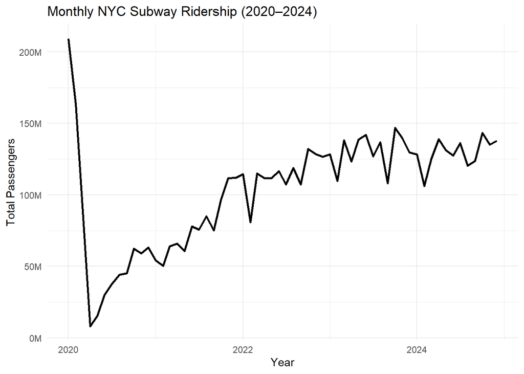

```r
df %>%
  group_by(month) %>%
  summarise(total_passengers = sum(num_passengers, na.rm = TRUE)) %>%
  ggplot(aes(x = month, y = total_passengers)) +
  geom_line(linewidth = 1) +
   scale_y_continuous(labels = scales::label_number(scale = 1e-6, suffix = "M")) +
  labs(
    title = "Monthly NYC Subway Ridership (2020–2024)",
    x = "Year",
    y = "Total Passengers"
  ) +
  theme_minimal()
```

## Lowest Performing Lines (2020–2024)

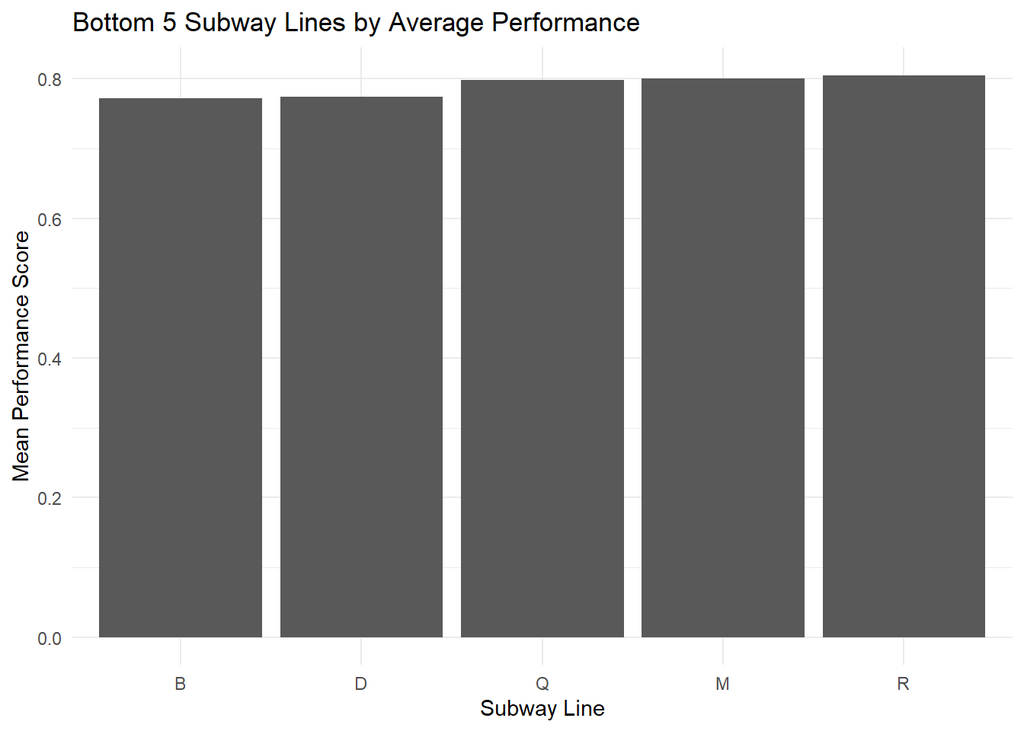

```r
df %>%
  group_by(line) %>%
  summarise(mean_performance = mean(perf_score, na.rm = TRUE)) %>%
  arrange(mean_performance) %>%
  slice(1:5) %>%
  ggplot(aes(x = reorder(line, mean_performance), y = mean_performance)) +
  geom_col() +
  labs(
    title = "Bottom 5 Subway Lines by Average Performance",
    x = "Subway Line",
    y = "Mean Performance Score"
  ) +
  theme_minimal()
```

**Interpretation:** These lines consistently perform below the system average and may benefit from focused operational review, especially during high-demand periods.

# Statistical Inference

## Delay Construction and Summary Statistics

```r
df_analysis <- df %>%
  mutate(total_delay = additional.platform.time + additional.train.time)

# Summary by division
df_analysis %>%
  group_by(division) %>%
  summarise(
    Avg_Performance = mean(perf_score, na.rm = TRUE),
    Avg_Delay = mean(total_delay, na.rm = TRUE),
    Total_Passengers = sum(num_passengers, na.rm = TRUE)
  )
```

```
## # A tibble: 2 × 4
##   division   Avg_Performance Avg_Delay Total_Passengers
##   <chr>                <dbl>     <dbl>            <dbl>
## 1 A DIVISION           0.890      1.28      2583101041.
## 2 B DIVISION           0.837      1.65      3666002146.
```

## Hypothesis Testing (T-Tests)

### A. Peak vs. Off-Peak Performance

**H0 (Null Hypothesis):** Mean performance is equal across Peak and Off-Peak periods.  
**H1 (Alternative Hypothesis):** Mean performance differs between Peak and Off-Peak periods.

```r
t.test(perf_score ~ period, data = df_analysis, conf.level = 0.95)
```

```
##
##  Welch Two Sample t-test
##
## data:  perf_score by period
## t = -10.565, df = 2848.2, p-value < 2.2e-16
## alternative hypothesis: true difference in means between group offpeak and group peak is not equal to 0
## 95 percent confidence interval:
##  -0.02752554 -0.01890765
## sample estimates:
## mean in group offpeak    mean in group peak
##             0.8426062             0.8658228
```

**Interpretation:** At 95% confidence, the p-value is below 0.05, so we reject the null hypothesis. Time of day has a statistically significant effect on subway journey performance.

### B. Division A vs. Division B Performance

**H0 (Null Hypothesis):** Mean performance is equal across divisions.  
**H1 (Alternative Hypothesis):** Mean performance differs between Division A and Division B.

```r
t.test(perf_score ~ division, data = df_analysis, conf.level = 0.95)
```

```
##
##  Welch Two Sample t-test
##
## data:  perf_score by division
## t = 28.306, df = 2654.7, p-value < 2.2e-16
## alternative hypothesis: true difference in means between group A DIVISION and group B DIVISION is not equal to 0
## 95 percent confidence interval:
##  0.04958302 0.05696385
## sample estimates:
## mean in group A DIVISION mean in group B DIVISION
##                0.8898420                0.8365686
```

**Interpretation:** At 95% confidence level, the p-value is below 0.05, so we reject the null hypothesis. The results indicate a statistically significant difference between mean performance between the two divisions.

# Correlation and Regression Analysis

## Relationship Between Delays and Performance

### Correlation

```r
cor_val <- cor(df_analysis$total_delay, df_analysis$perf_score)
cor_val
```

```
## [1] -0.7892036
```

A strong negative correlation shows that higher total delays are closely associated with lower journey performance scores.

### Linear Regression Model

Given the earlier finding, a regression model is used to quantify how delays relate to journey performance.

```r
perf_model <- lm(perf_score ~ total_delay, data = df_analysis)
summary(perf_model)
```

```
##
## Call:
## lm(formula = perf_score ~ total_delay, data = df_analysis)
##
## Residuals:
##       Min        1Q    Median        3Q       Max
## -0.192424 -0.024993 -0.004476  0.025077  0.182982
##
## Coefficients:
##               Estimate Std. Error t value Pr(>|t|)
## (Intercept)  0.9467452  0.0015132  625.66   <2e-16 ***
## total_delay -0.0605432  0.0008819  -68.65   <2e-16 ***
## ---
## Signif. codes:  0 '***' 0.001 '**' 0.01 '*' 0.05 '.' 0.1 ' ' 1
##
## Residual standard error: 0.03676 on 2854 degrees of freedom
## Multiple R-squared:  0.6228, Adjusted R-squared:  0.6227
## F-statistic:  4713 on 1 and 2854 DF,  p-value: < 2.2e-16
```

**Interpretation:** The model shows that total delay is a strong predictor of journey performance. The high R-squared value indicates that delays explain a large share of the variation in performance.

The Regression Equation
$$\text{Performance Score} = 0.9467 - 0.0605 \times
(\text{Total Delay})$$

### Visualization: Delay vs. Performance

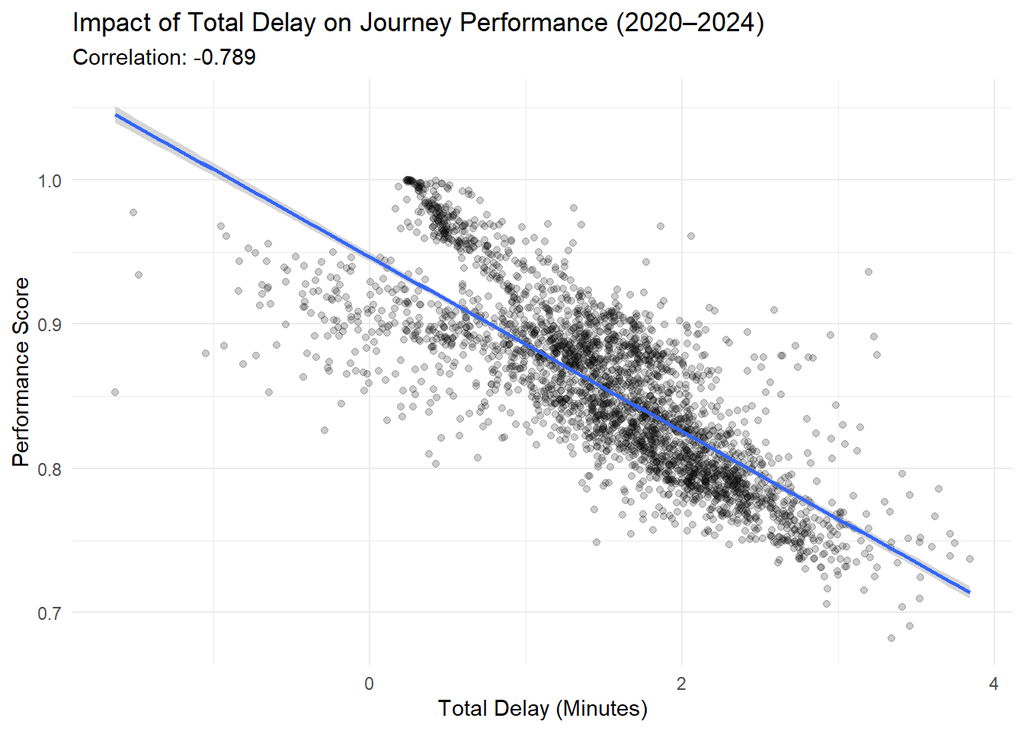

```r
ggplot(df_analysis, aes(x = total_delay, y = perf_score)) +
  geom_point(alpha = 0.2) +
  geom_smooth(method = "lm") +
  labs(
    title = "Impact of Total Delay on Journey Performance (2020–2024)",
    subtitle = paste("Correlation:", round(cor_val, 3)),
    x = "Total Delay (Minutes)",
    y = "Performance Score"
  ) +
  theme_minimal()
```

# Key Takeaways